# R Notebook

# chapter 10. Data visualization

자, 이제 직접 해보자!

## 10.1 Case study : new insights on poverty

아래의 두 질문에 답해보자. `gapminder` dataset을 이용할 것이다. > 1. Is it a fair characterization of today’s world to say it is divided into western rich nations and the developing world in Africa, Asia and Latin America? > 2. Has income inequality across countries worsened during the last 40 years?

```r
library(tidyverse)
library(dslabs)
data(gapminder)
gapminder %>% as_tibble()
```

| country | year | infant_mortality | life_expectancy | fertility | population | gdp | continent | region |
| --- | --- | --- | --- | --- | --- | --- | --- | --- |
| Albania | 1960 | 115.40 | 62.87 | 6.19 | 1636054 | NA | Europe | Southern Europe |
| Algeria | 1960 | 148.20 | 47.50 | 7.65 | 11124892 | 1.382815e+10 | Africa | Northern Africa |
| Angola | 1960 | 208.00 | 35.98 | 7.32 | 5270844 | NA | Africa | Middle Africa |
| Antigua and Barbuda | 1960 | NA | 62.97 | 4.43 | 54681 | NA | Americas | Caribbean |
| Argentina | 1960 | 59.87 | 65.39 | 3.11 | 20619075 | 1.083223e+11 | Americas | South America |
| Armenia | 1960 | NA | 66.86 | 4.55 | 1867396 | NA | Asia | Western Asia |
| Aruba | 1960 | NA | 65.66 | 4.82 | 54208 | NA | Americas | Caribbean |
| Australia | 1960 | 20.30 | 70.87 | 3.45 | 10292328 | 9.667786e+10 | Oceania | Australia and New Zealand |
| Austria | 1960 | 37.30 | 68.75 | 2.70 | 7065525 | 5.239270e+10 | Europe | Western Europe |
| Azerbaijan | 1960 | NA | 61.33 | 5.57 | 3897889 | NA | Asia | Western Asia |

[output cut: 990 more lines]

### 10.1.1 Hans Rosling’s quiz

아래 국가 중 유아 사망률이 높은 쪽은 어디일까? 1. Sri Lanka or Turkey 2. Poland or South Korea 3. Malaysia or Russia 4. Pakistan or Vietnam 5. Thailand or South Africa

```r
gapminder %>%
  filter(year == 2015 & country %in% c("Sri Lanka", "Turkey")) %>%
  select(country, infant_mortality)
```

| country | infant_mortality |
| --- | --- |
| Sri Lanka | 8.4 |
| Turkey | 11.6 |

## 10.2 Scatterplots

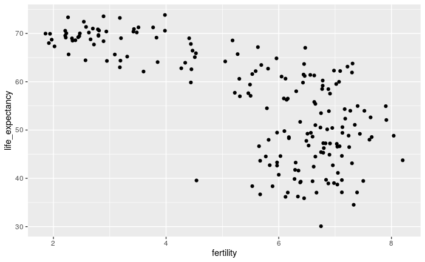

```r
gapminder %>% filter(., year == 1962) %>%
  ggplot(aes(fertility, life_expectancy)) +
  geom_point()
```

대륙 별 분포를 확인하기 위해 색을 입히자.

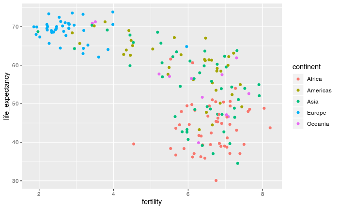

```r
gapminder %>% filter(., year == 1962) %>%
  ggplot(aes(fertility, life_expectancy, color = continent)) +
  geom_point()
```

1962년과 2012년을 비교할 수 있을까?

## 10.3 Faceting

두 해의 데이터를 비교하려면 각 해의 plot을 나란히 놓는 것이 좋을 것이다. **faceting** 변수로 가능하다. `facet_grid` 함수는 두 plot을 자동으로 나눠준다.

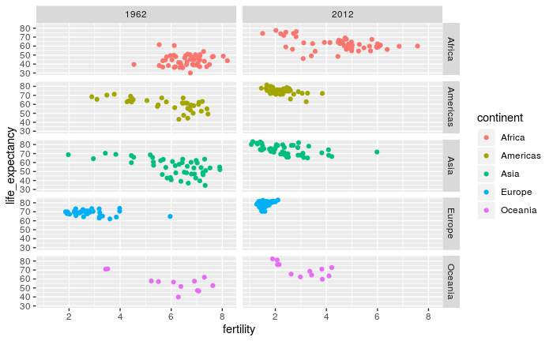

```r
gapminder %>% filter(., year %in% c(1962, 2012)) %>%
  ggplot(aes(fertility, life_expectancy, color = continent)) +
  geom_point() +
  facet_grid(continent~year) #row~column 순서이다.
```

facet_grid는 두 변수를 입력받아 각각 column과 row로 만든다. 만약 한 변수만 쓰려면 `.`으로 대체해주자.

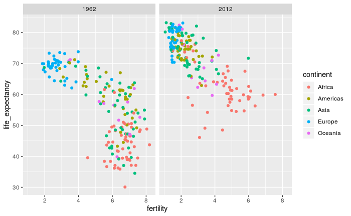

```r
gapminder %>% filter(., year %in% c(1962, 2012)) %>%
  ggplot(aes(fertility, life_expectancy, color = continent)) +
  geom_point() +
  facet_grid(.~year)
```

### 10.3.1 facet_wrap

`facet_grid`는 동일한 row에 plot을 올린다 그럴 필요가 없는 경우 `facet_wrap`을 사용할 수 있다.

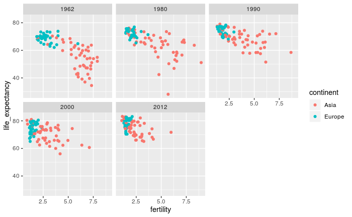

```r
years <- c(1962, 1980, 1990, 2000, 2012)
continents <- c("Europe", "Asia")
gapminder %>%
  filter(year %in% years & continent %in% continents) %>%
  ggplot(aes(fertility, life_expectancy, col = continent)) +
  geom_point() +
  facet_wrap(~year)
```

### 10.3.2 Fixed Scales for vetter comparisons

plot을 따로 만들면 스케일이 제멋대로다. facet을 쓰는 것이 좋다.

## 10.4 Time series plots

50년 동안 얼마나 변화했는지를 확인해보자.

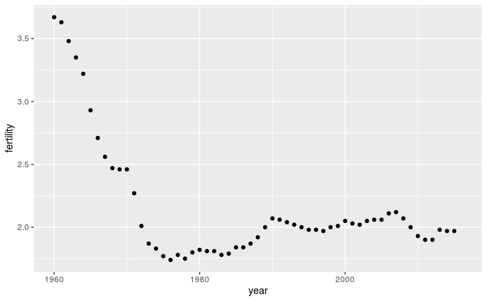

```r
gapminder %>%
  filter(country == "United States") %>%
  ggplot(aes(year, fertility)) +
  geom_point()
```

선으로 그려보자.

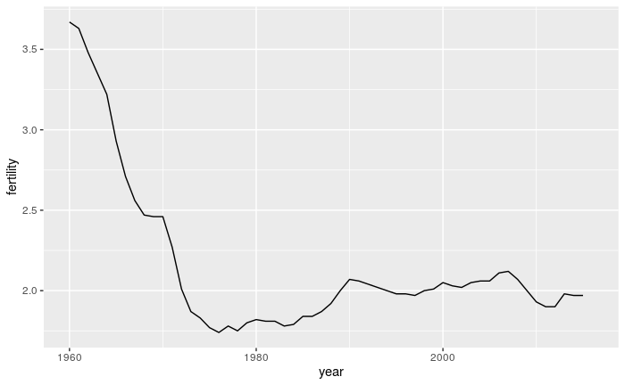

```r
gapminder %>%
  filter(country == "United States") %>%
  ggplot(aes(year, fertility)) +
  geom_line()
```

한국을 넣어보자.

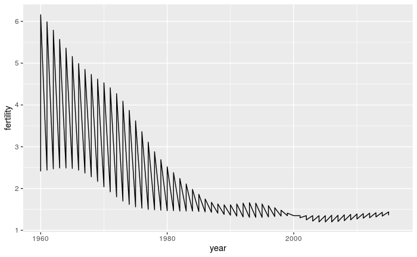

```r
countries <- c("South Korea","Germany")
gapminder %>% filter(country %in% countries) %>%
  ggplot(aes(year,fertility)) +
  geom_line()
```

망했다! `group`으로 묶어줘야 한다.

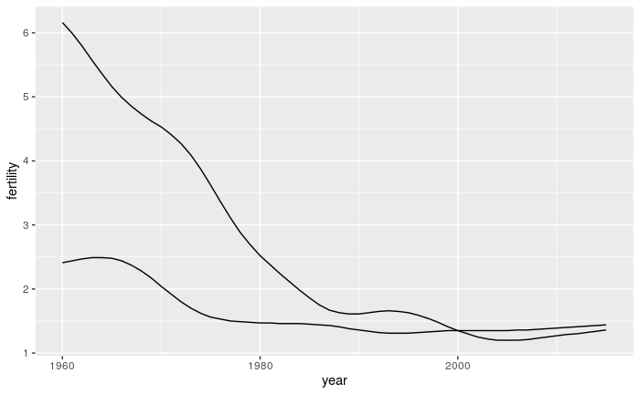

```r
countries <- c("South Korea","Germany")

gapminder %>% filter(country %in% countries & !is.na(fertility)) %>% #is.na()는 없는 값, 즉 NA를 가리킨다. 즉 !is.na()는 ()내에서 NA를 제외하는 것이다.
  ggplot(aes(year, fertility, group = country)) +
  geom_line()
```

색으로 국가를 표시하자.

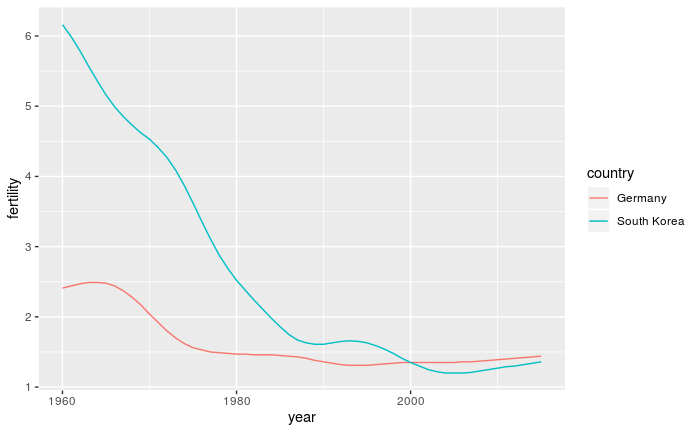

```r
countries <- c("South Korea","Germany")

gapminder %>% filter(country %in% countries & !is.na(fertility)) %>%
  ggplot(aes(year,fertility, col = country)) +
  geom_line()
```

## 10.4.1 Labels instead of legends

제곧내

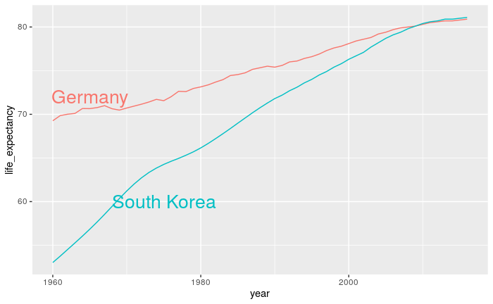

```r
labels <- data.frame(country = countries, x = c(1975,1965), y = c(60,72)) #아까 countries를 독일과 남한으로 지정했었다.

gapminder %>%
  filter(country %in% countries) %>%
  ggplot(aes(year, life_expectancy, col = country)) +
  geom_line() +
  geom_text(data = labels, aes(x, y, label = country), size = 7) +
  theme(legend.position = "none")
```

## 10.5 Data Transformations

gapminder는 GDP를 포함한다. GDP는 전체 국민의 1년에 해당한다. 1일, 1명으로 따져보자. 2달러 미만은 절대적 빈곤이라고 정의된다.

```r
gapminder <- gapminder %>% mutate(dollars_per_day = gdp/population/365)
```

## 10.5.1 Log Transformation

70년대를 확인해보자.

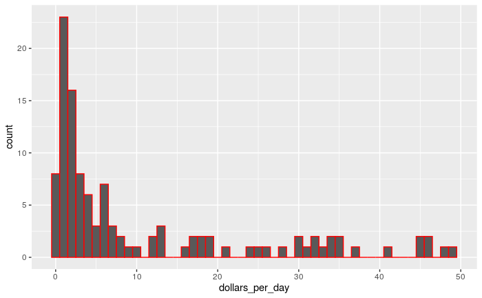

```r
past_year <- 1970
gapminder %>%
  filter(year == past_year & !is.na(gdp)) %>%
  ggplot(aes(dollars_per_day)) +
  geom_histogram(binwidth = 1, color = "red")
```

1-2-4-8-16-32-64로 수익을 나눠보자. 이는 로그스케일로 확인할 수 있다.

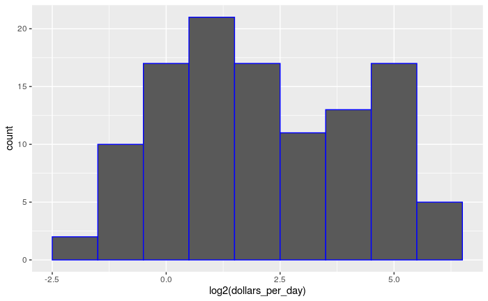

```r
gapminder %>%
  filter(year == past_year & !is.na(gdp)) %>%
  ggplot(aes(log2(dollars_per_day))) +
  geom_histogram(binwidth = 1, color = "blue")
```

### 10.5.2 Which Base?

상용로그로 만들어보자. 우선 상용로그로 했을 경우의 범위를 확인해보자.

```r
filter(gapminder, year == past_year) %>% #1970년을 말하는거다.
  summarize(min = min(population), max = max(population))
```

| min | max |
| --- | --- |
| 46075 | 808510713 |

히토스그램을 만들어보자!

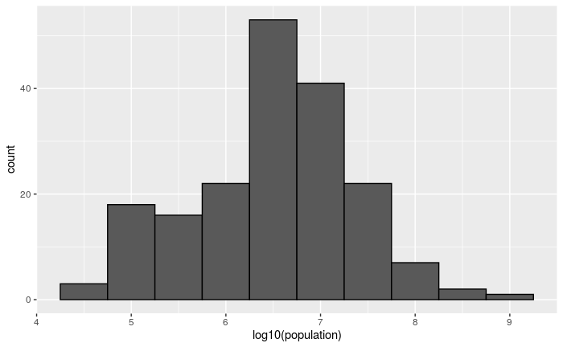

```r
gapminder %>%
  filter(year == past_year) %>%
  ggplot(aes(log10(population))) +
  geom_histogram(binwidth = 0.5, color = "black")
```

### 10.5.3 Transform the values or scale?

스케일에 로그를 쓸 수도 있고 데이터에 로그를 쓸 수도 있다. 전자는 본래 데이터에 변형이 가해지지 않으므로 해석이 쉽다는 장점을 가진다.

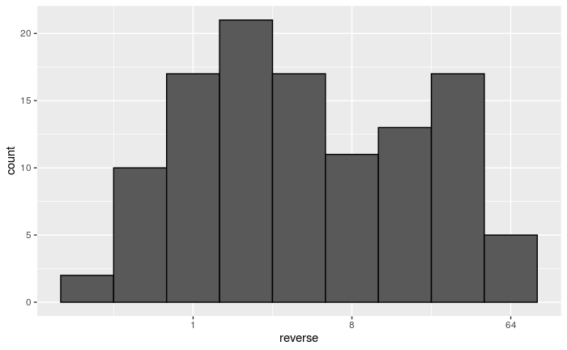

```r
gapminder %>%
  filter(year == past_year & !is.na(gdp)) %>%
  ggplot(aes(dollars_per_day)) +
  geom_histogram(binwidth = 1, color = "black") +
  scale_x_continuous(trans = "log2", "reverse")
```

`trans` 대신 `sqrt`를 써서 근으로 만들 수도 있고, `logit`로 0과 1사이 값 중 하나로 만들 수도 있다. `reverse`는 방향을 반대로 만들어준다.

## 10.6 Visualizing multimodal distributions

mode는 히스토그램 등의 plot에서 나타나는 bump를 지칭한다. 정규분포에서 mode는 평균을 의미한다. 대부분의 plot에서는 bump 이후 값이 감소하지 않는다. 때문에 각각의 bump를 local modes라고 하고, multiple modes를 가진다고 한다. (극대값을 말하는 것 같다.)

## 10.7 Comparing multiple distributions with boxplots and ridge plots

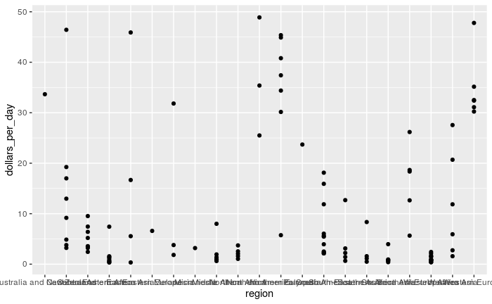

```r
p <- gapminder %>%
  filter(year == past_year & !is.na(gdp)) %>%
  ggplot(aes(region, dollars_per_day))
p + geom_point()
```

X 축이 엉망이다. `coord_filp`이나 `theme`으로 조절 가능하다.

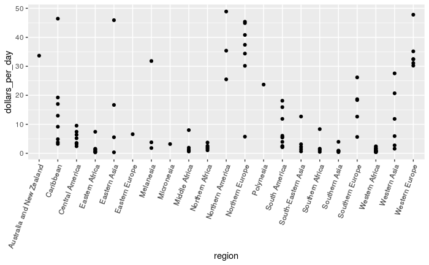

```r
p + geom_point() +
  theme(axis.text.x = element_text(angle = 70, hjust =1))
```

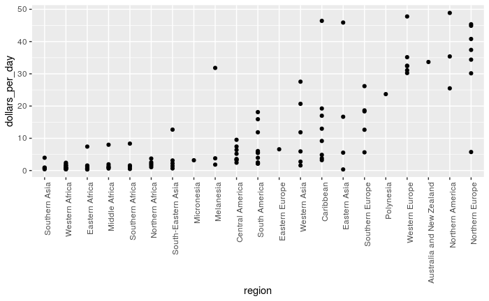

```r
p <- gapminder %>%
  filter(year == past_year & !is.na(gdp)) %>%
  mutate(region = reorder(region, dollars_per_day, FUN = median)) %>%
  ggplot(aes(region, dollars_per_day)) +
  geom_point() +
  theme(axis.text.x = element_text(angle = 90, hjust = 1))
p
```

로그로 확인하자.

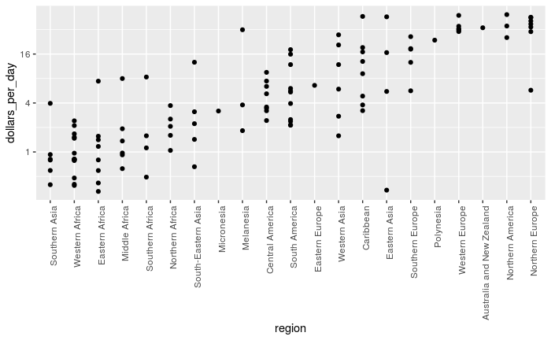

```r
p + scale_y_continuous(trans = "log2")
```

### 10.7.1 Boxplots

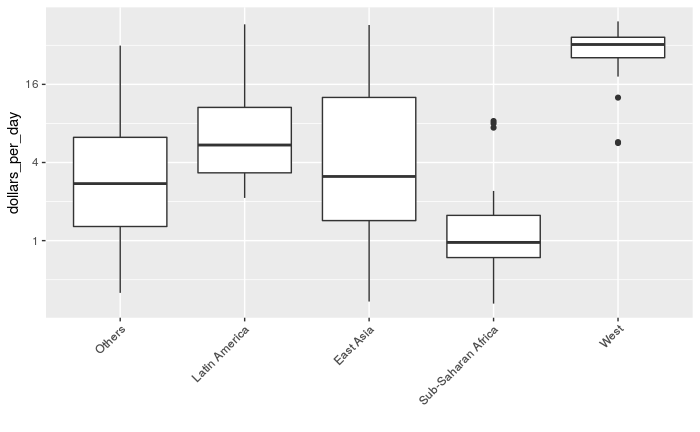

```r
gapminder <- gapminder %>%
  mutate(group = case_when(
    region %in% c("Western Europe", "Northern Europe","Southern Europe",
                    "Northern America", "Australia and New Zealand") ~ "West",
    region %in% c("Eastern Asia", "South-Eastern Asia") ~ "East Asia",
    region %in% c("Caribbean", "Central America", "South America") ~ "Latin America",
    continent == "Africa" & region != "Northern Africa" ~ "Sub-Saharan Africa",
    TRUE ~ "Others"))

gapminder <- gapminder %>%
  mutate(group = factor(group,
                        levels = c("Others", "Latin America", "East Asia", "Sub-Saharan Africa", "West")))

p <- gapminder %>%
  filter(year == past_year & !is.na(gdp)) %>%
  ggplot(aes(group, dollars_per_day)) +
  geom_boxplot() +
  theme(axis.text.x = element_text(angle = 45, hjust = 1)) +
  scale_y_continuous(trans = "log2") +
  xlab("")
p
```

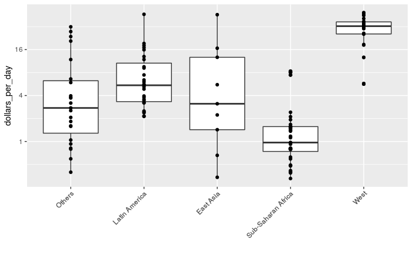

```r
p + geom_point(alpha = 1)
```

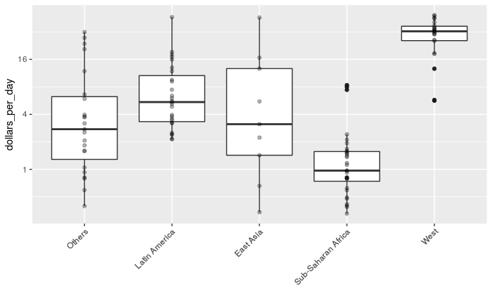

```r
p + geom_point(alpha = 0.3)
```

### 10.7.2 Ridge plots

ridge plots는 ggridges라는 패키지가 필요하다.

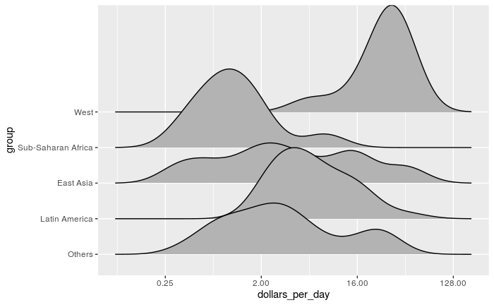

```r
library(ggridges)
p <- gapminder %>%
  filter(year == past_year & !is.na(dollars_per_day)) %>%
  ggplot(aes(dollars_per_day, group)) +
  scale_x_continuous(trans = "log2")
p  + geom_density_ridges(scale = 3)
```

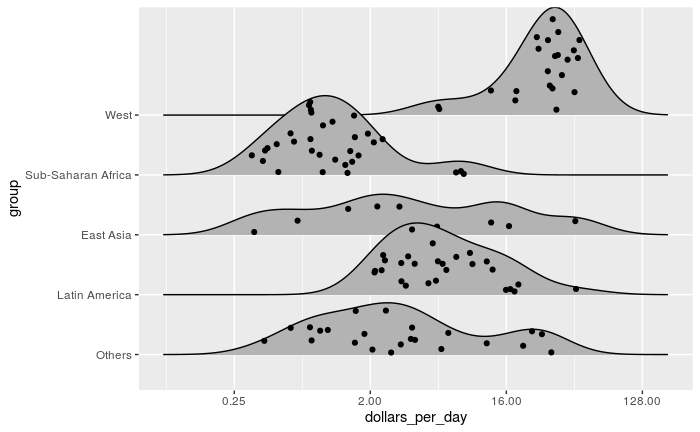

```r
p + geom_density_ridges(jittered_points = TRUE)
```

rug representation을 확인해보자.

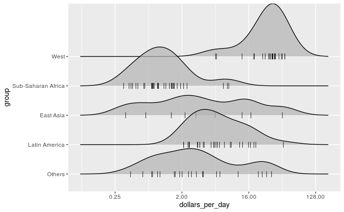

```r
p + geom_density_ridges(jittered_points = TRUE,
                        position = position_points_jitter(width = 0.05, height = 0),
                        point_shape = '|', point_size = 3, point_alpha = 1, alpha = 0.7)
```

### 10.7.3 Example: 1970 versus 2010 income distributions

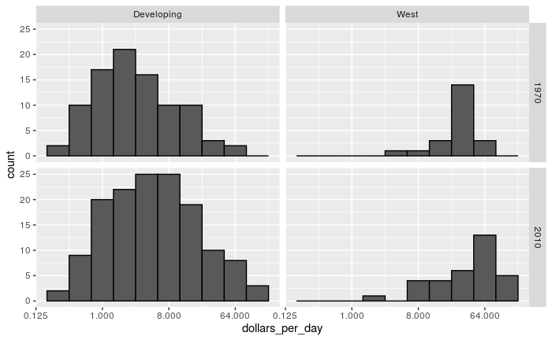

```r
past_year <- 1970
present_year <- 2010
gapminder %>%
  filter(year %in% c(past_year, present_year) & !is.na(gdp)) %>%
  mutate(west = ifelse(group == "West", "West", "Developing")) %>%
  ggplot(aes(dollars_per_day)) +
  geom_histogram(binwidth = 1, color = "black") +
  scale_x_continuous(trans = "log2") +
  facet_grid(year ~ west)
```

1970과 2010 사이에서 국가의 수가 달라졌다. 따라서 두 시기에 모두 존재한 국가만 걸러보자. **tidyverse**의 `intersect`함수로 할 수 있다.

```r
country_list_1 <- gapminder %>%
  filter(year == past_year & !is.na(dollars_per_day)) %>%
  pull(country)

country_list_2 <- gapminder %>%
  filter(year == present_year & !is.na(dollars_per_day)) %>%
  pull(country)

country_list <- intersect(country_list_1, country_list_2)
```

이제 다시 만들어보자.

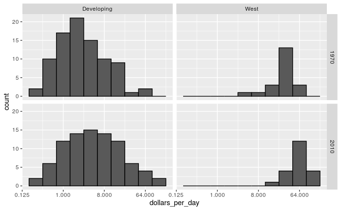

```r
past_year <- 1970
present_year <- 2010
gapminder %>%
  filter(country %in% country_list) %>%
  filter(year %in% c(past_year, present_year) & !is.na(gdp)) %>%
  mutate(west = ifelse(group == "West", "West", "Developing")) %>%
  ggplot(aes(dollars_per_day)) +
  geom_histogram(binwidth = 1, color = "black") +
  scale_x_continuous(trans = "log2") +
  facet_grid(year ~ west)
```

그룹 별로 boxplot으로 확인해보자.

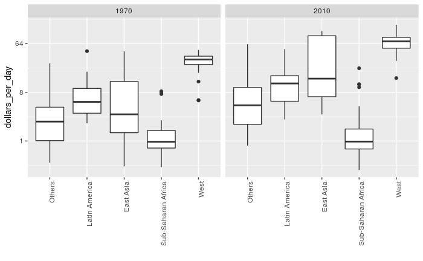

```r
gapminder %>%
  filter(year %in% c(past_year, present_year) & country %in% country_list) %>%
  ggplot(aes(group, dollars_per_day)) +
  geom_boxplot() +
  theme(axis.text.x = element_text(angle = 90, hjust = 1)) +
  scale_y_continuous(trans = "log2") +
  xlab("") + # 이게 없으면 group 레이블이 보인다.
  facet_grid(. ~ year)
```

이렇게 보면 비교가 어렵다. 한번에 색으로 보게 해보자.

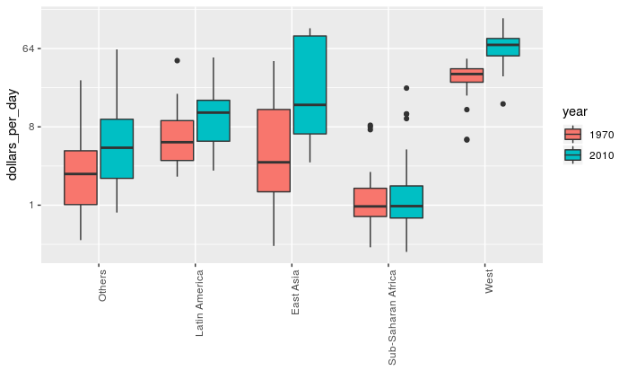

```r
gapminder %>%
  filter(year %in% c(past_year, present_year) & country %in% country_list) %>%
  mutate(year = factor(year)) %>% # 년도를 numeric이 아니라 factor로 인식하게 해야 이걸로 분리할 수 있다.
  ggplot(aes(group, dollars_per_day, fill = year)) +
  geom_boxplot() +
  theme(axis.text.x = element_text(angle = 90, hjust = 1)) +
  scale_y_continuous(trans = "log2") +
  xlab("")
```

Density plot으로 확인해보자.

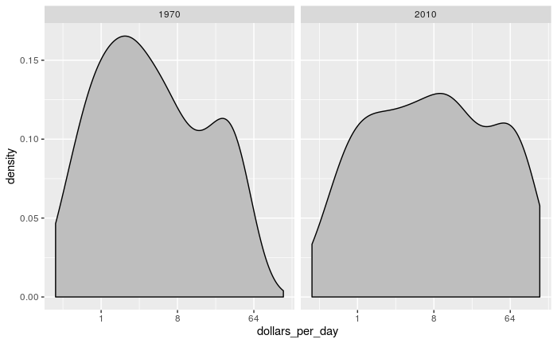

```r
gapminder %>%
  filter(year %in% c(past_year, present_year) & country %in% country_list) %>%
  ggplot(aes(dollars_per_day)) +
  geom_density(fill = "grey") +
  scale_x_continuous(trans = "log2") +
  facet_grid(. ~ year)
```

일부 개발 도상국이 선진국이 되었다. 이 현상의 이유를 찾을 필요가 있겠다.

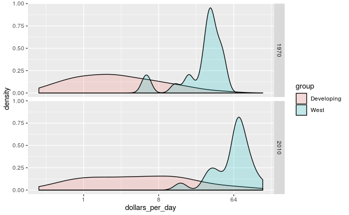

```r
gapminder %>%
  filter(year %in% c(past_year, present_year) & country %in% country_list) %>%
  mutate(group = ifelse(group == "West", "West", "Developing")) %>%
  ggplot(aes(dollars_per_day, fill = group)) +
  scale_x_continuous(trans = "log2") +
  geom_density(alpha = 0.2) +
  facet_grid(year ~ .)
```

두 국가 그룹 내의 국가 수가 같은 것 처럼 보인다. 실제로는 다르다. 이 부분을 조절해줄 필요가 있다.